# Diamonds - EDA

RavMin

March 6, 2017

### Diamonds Dataset - Exploratory Data Analysis

```r
library(ggplot2)

summary(diamonds)
```

```
##      carat               cut        color        clarity
##  Min.   :0.2000   Fair     : 1610   D: 6775   SI1    :13065
##  1st Qu.:0.4000   Good     : 4906   E: 9797   VS2    :12258
##  Median :0.7000   Very Good:12082   F: 9542   SI2    : 9194
##  Mean   :0.7979   Premium  :13791   G:11292   VS1    : 8171
##  3rd Qu.:1.0400   Ideal    :21551   H: 8304   VVS2   : 5066
##  Max.   :5.0100                     I: 5422   VVS1   : 3655
##                                     J: 2808   (Other): 2531
##      depth           table           price             x
##  Min.   :43.00   Min.   :43.00   Min.   :  326   Min.   : 0.000
##  1st Qu.:61.00   1st Qu.:56.00   1st Qu.:  950   1st Qu.: 4.710
##  Median :61.80   Median :57.00   Median : 2401   Median : 5.700
##  Mean   :61.75   Mean   :57.46   Mean   : 3933   Mean   : 5.731
##  3rd Qu.:62.50   3rd Qu.:59.00   3rd Qu.: 5324   3rd Qu.: 6.540
##  Max.   :79.00   Max.   :95.00   Max.   :18823   Max.   :10.740
##
##        y                z
##  Min.   : 0.000   Min.   : 0.000
##  1st Qu.: 4.720   1st Qu.: 2.910
##  Median : 5.710   Median : 3.530
##  Mean   : 5.735   Mean   : 3.539
##  3rd Qu.: 6.540   3rd Qu.: 4.040
##  Max.   :58.900   Max.   :31.800
##
```

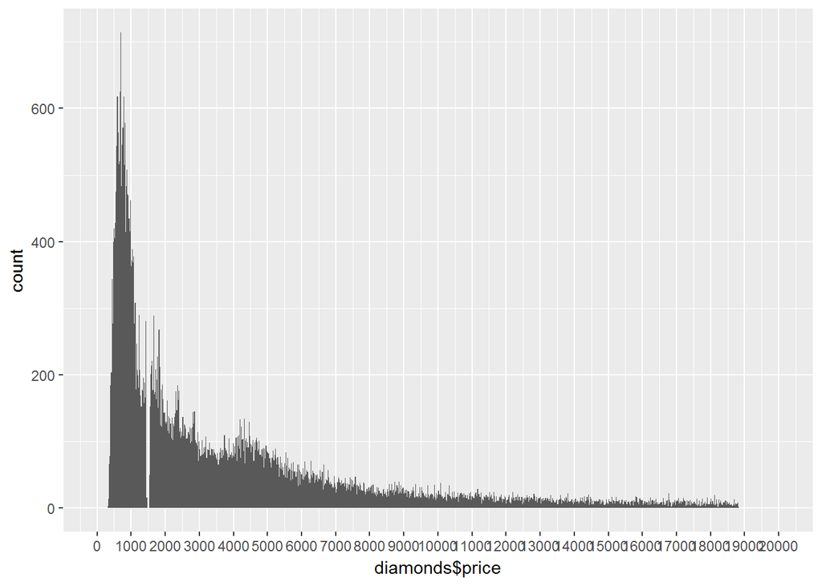

```r
qplot(x= diamonds$price, data = diamonds, binwidth = 20)+
  scale_x_continuous(limits = c(0, 20000), breaks = seq(0, 20000,1000))
```

### We can see that the price distribution is POSITIVELY SKEWED. Lets try to look closer on peak price data.

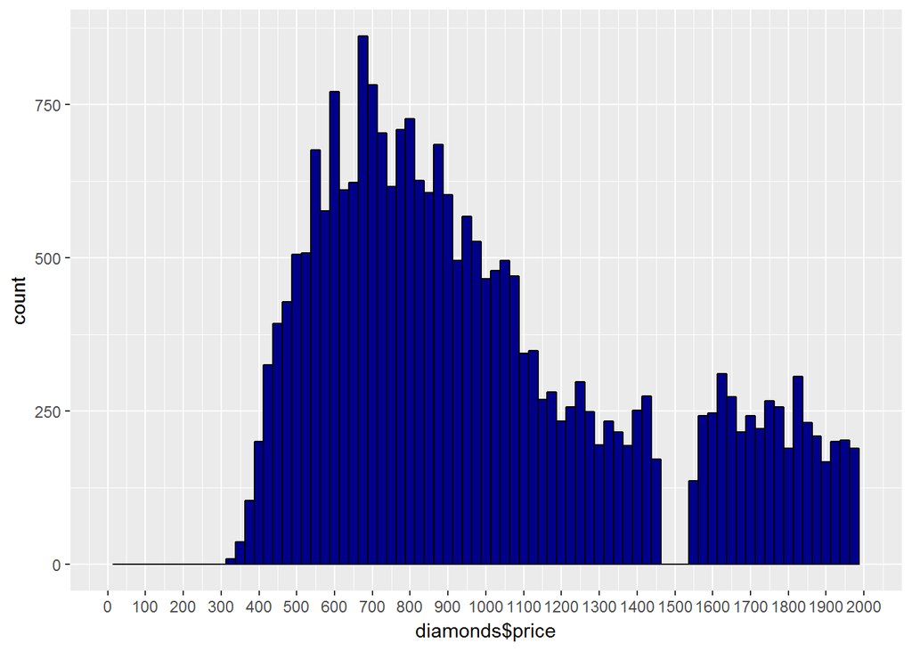

```r
qplot(x= diamonds$price, data = subset(diamonds, !is.na(price)),
      binwidth = 25,
      color = I('black'), fill = I('dark blue'))+
  scale_x_continuous(limits = c(0,2000), breaks = seq(0,2000, 100))
```

### We can see that there are no diamonds in the price range below $300(obviously!)

### But interestingly there are few diamonds in the price range $1450-1575 (approx range)

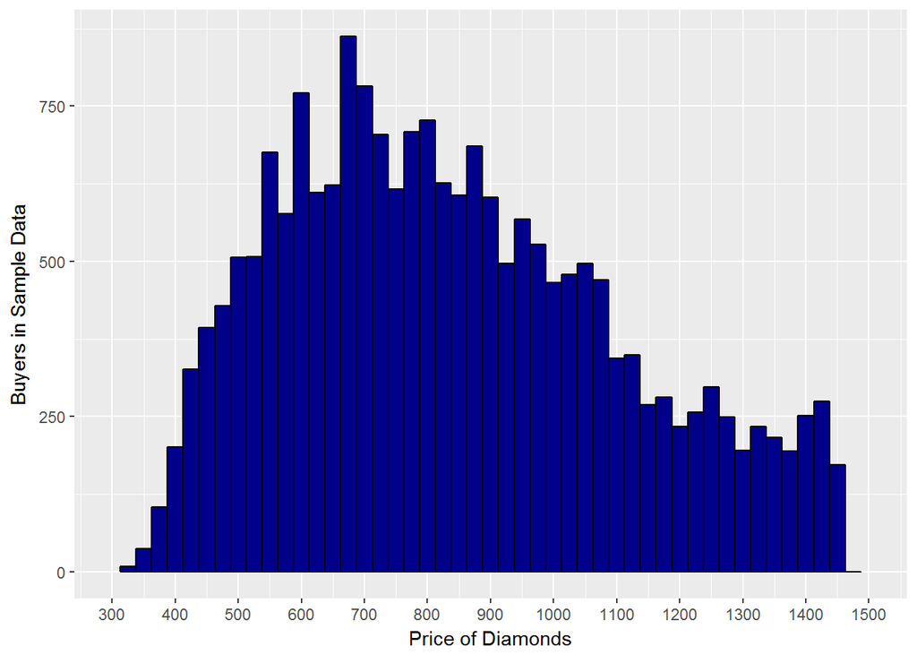

```r
qplot(x= diamonds$price, data = subset(diamonds, !is.na(price)),
      binwidth = 25,
      xlab = 'Price of Diamonds',
      ylab= 'Buyers in Sample Data',
      color = I('black'), fill = I('dark blue'))+
  scale_x_continuous(limits = c(300,1500), breaks = seq(300,1500, 100))
```

### Exploring and Faceting the PRICE of diamonds by its CUT

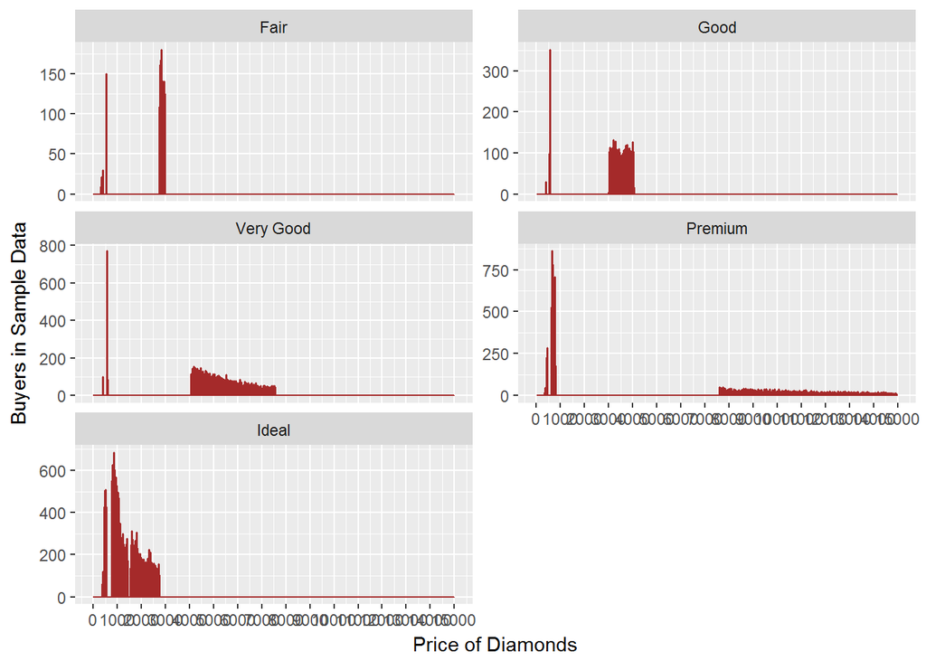

```r
qplot(x= diamonds$price, data = subset(diamonds, !is.na(price)),
      binwidth = 25,
      xlab = 'Price of Diamonds',
      ylab= 'Buyers in Sample Data',
      color = I('brown'), fill = I('yellow'))+
  scale_x_continuous(limits = c(0, 15000), breaks = seq(0, 15000,1000))+
  facet_wrap(~cut, ncol = 2, scales = 'free_y')
```

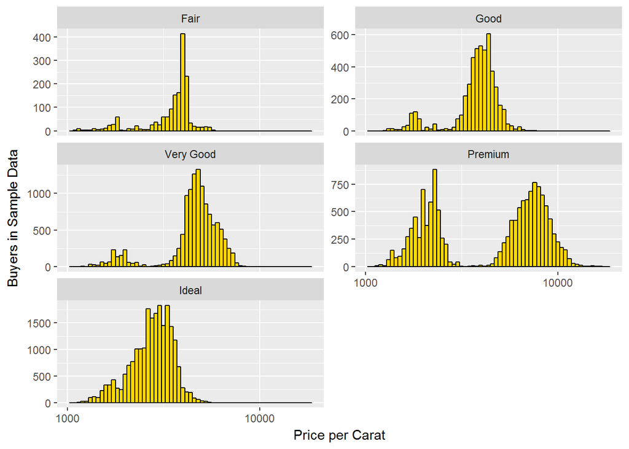

```r
qplot(x= diamonds$price/diamonds$carat, data = subset(diamonds, !is.na(price)),
      binwidth = .02,
      xlab = 'Price per Carat',
      ylab= 'Buyers in Sample Data',
      color = I('black'), fill = I('Gold'))+
  facet_wrap(~cut, ncol = 2, scales = 'free_y')+
  scale_x_log10()
```

# Summary of statistical values of Price of diamonds by CUT

```r
by(diamonds$price, diamonds$cut, summary)
```

```
## diamonds$cut: Fair
##    Min. 1st Qu.  Median    Mean 3rd Qu.    Max.
##     337    2050    3282    4359    5206   18570
## --------------------------------------------------------
## diamonds$cut: Good
##    Min. 1st Qu.  Median    Mean 3rd Qu.    Max.
##     327    1145    3050    3929    5028   18790
## --------------------------------------------------------
## diamonds$cut: Very Good
##    Min. 1st Qu.  Median    Mean 3rd Qu.    Max.
##     336     912    2648    3982    5373   18820
## --------------------------------------------------------
## diamonds$cut: Premium
##    Min. 1st Qu.  Median    Mean 3rd Qu.    Max.
##     326    1046    3185    4584    6296   18820
## --------------------------------------------------------
## diamonds$cut: Ideal
##    Min. 1st Qu.  Median    Mean 3rd Qu.    Max.
##     326     878    1810    3458    4678   18810
```

# BOX PLOT for Price of diamonds by cut

### The Cartesian coordinate system is the most familiar, and common, type of coordinate system. Setting limits on the coordinate system will zoom the plot (like you’re looking at it with a magnifying glass), and will not change the underlying data like setting limits on a scale will.

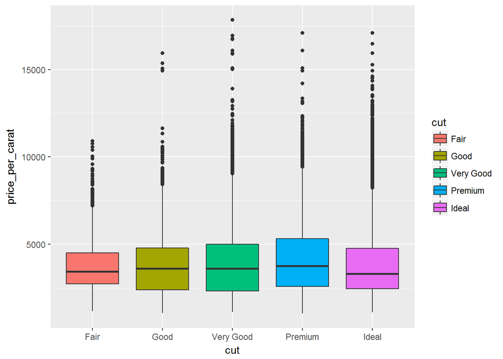

```r
diamonds$price_per_carat<-as.integer(diamonds$price/diamonds$carat)

qplot(x= cut, y = price_per_carat, data = subset(diamonds, !is.na(price)),
      geom = 'boxplot',
      fill= cut)
```

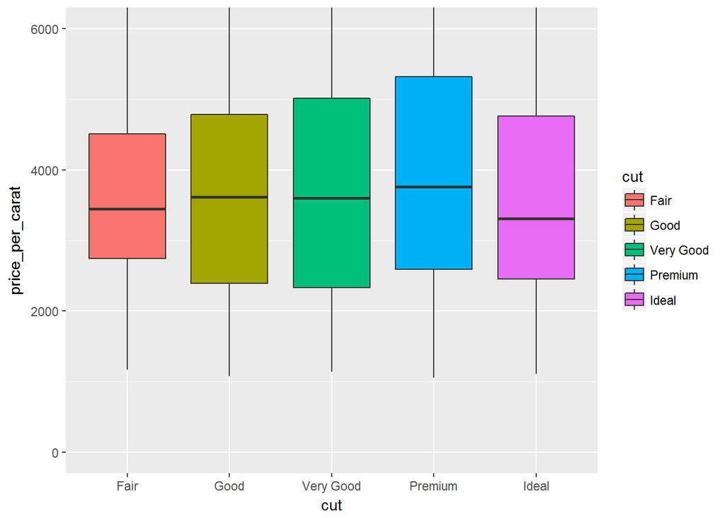

```r
qplot(x= cut, y = price_per_carat, data = subset(diamonds, !is.na(price)),
      geom = 'boxplot',
      fill= cut)+
  coord_cartesian(ylim=c(0,6000))
```

### # BOX PLOT for Price of diamonds by clarity

```r
by(diamonds$price, diamonds$clarity, summary)
```

```
## diamonds$clarity: I1
##    Min. 1st Qu.  Median    Mean 3rd Qu.    Max.
##     345    2080    3344    3924    5161   18530
## --------------------------------------------------------
## diamonds$clarity: SI2
##    Min. 1st Qu.  Median    Mean 3rd Qu.    Max.
##     326    2264    4072    5063    5777   18800
## --------------------------------------------------------
## diamonds$clarity: SI1
##    Min. 1st Qu.  Median    Mean 3rd Qu.    Max.
##     326    1089    2822    3996    5250   18820
## --------------------------------------------------------
## diamonds$clarity: VS2
##    Min. 1st Qu.  Median    Mean 3rd Qu.    Max.
##     334     900    2054    3925    6024   18820
## --------------------------------------------------------
## diamonds$clarity: VS1
##    Min. 1st Qu.  Median    Mean 3rd Qu.    Max.
##     327     876    2005    3839    6023   18800
## --------------------------------------------------------
## diamonds$clarity: VVS2
##    Min. 1st Qu.  Median    Mean 3rd Qu.    Max.
##   336.0   794.2  1311.0  3284.0  3638.0 18770.0
## --------------------------------------------------------
## diamonds$clarity: VVS1
##    Min. 1st Qu.  Median    Mean 3rd Qu.    Max.
##     336     816    1093    2523    2379   18780
## --------------------------------------------------------
## diamonds$clarity: IF
##    Min. 1st Qu.  Median    Mean 3rd Qu.    Max.
##     369     895    1080    2865    2388   18810
```

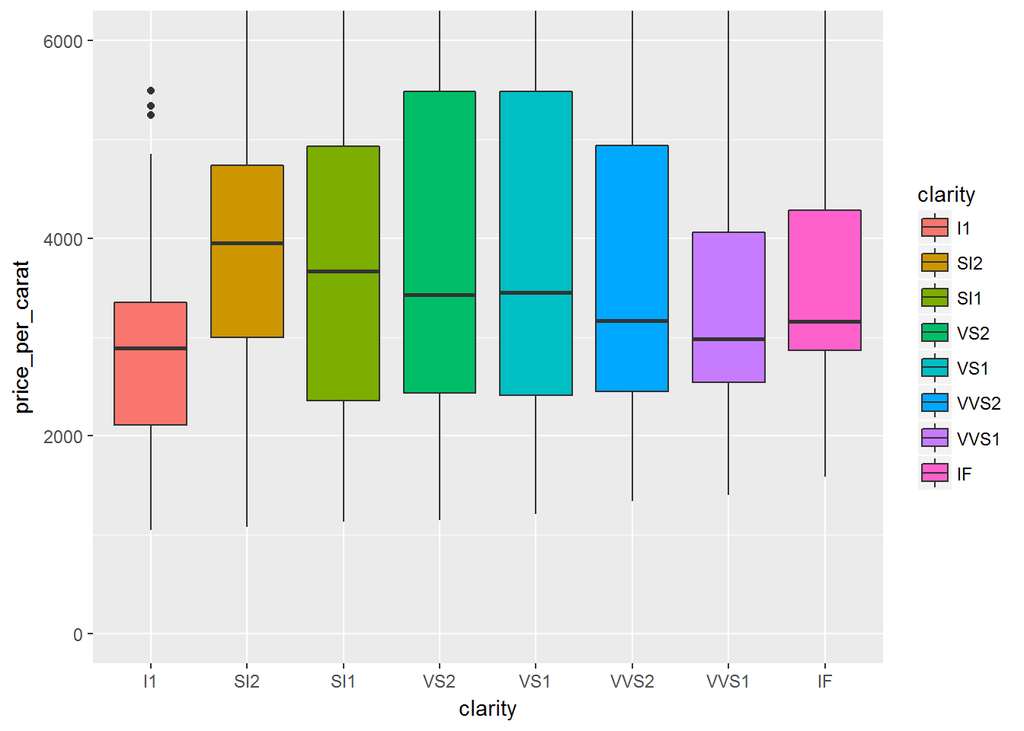

```r
qplot(x= clarity, y = price_per_carat, data = subset(diamonds, !is.na(price)),
      geom = 'boxplot', fill= clarity)+
  coord_cartesian(ylim=c(0,6000))
```

# BOX PLOT for Price of diamonds by Color

```r
by(diamonds$price, diamonds$color, summary)
```

```
## diamonds$color: D
##    Min. 1st Qu.  Median    Mean 3rd Qu.    Max.
##     357     911    1838    3170    4214   18690
## --------------------------------------------------------
## diamonds$color: E
##    Min. 1st Qu.  Median    Mean 3rd Qu.    Max.
##     326     882    1739    3077    4003   18730
## --------------------------------------------------------
## diamonds$color: F
##    Min. 1st Qu.  Median    Mean 3rd Qu.    Max.
##     342     982    2344    3725    4868   18790
## --------------------------------------------------------
## diamonds$color: G
##    Min. 1st Qu.  Median    Mean 3rd Qu.    Max.
##     354     931    2242    3999    6048   18820
## --------------------------------------------------------
## diamonds$color: H
##    Min. 1st Qu.  Median    Mean 3rd Qu.    Max.
##     337     984    3460    4487    5980   18800
## --------------------------------------------------------
## diamonds$color: I
##    Min. 1st Qu.  Median    Mean 3rd Qu.    Max.
##     334    1120    3730    5092    7202   18820
## --------------------------------------------------------
## diamonds$color: J
##    Min. 1st Qu.  Median    Mean 3rd Qu.    Max.
##     335    1860    4234    5324    7695   18710
```

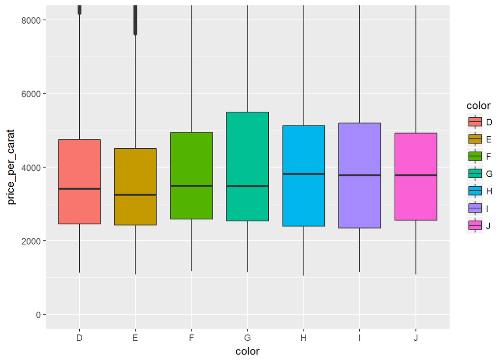

```r
qplot(x= color, y = price_per_carat, data = subset(diamonds, !is.na(price)),
      geom = 'boxplot', fill = color)+
  coord_cartesian(ylim=c(0,8000))
```

### Checking the interquatile range for the boxplots

```r
IQR(subset(diamonds, color=='D')$price)
```

```
## [1] 3302.5
```

```r
IQR(subset(diamonds, color=='J')$price)
```

```
## [1] 5834.5
```

### Frequency Polygon for weight(carat) of diamonds

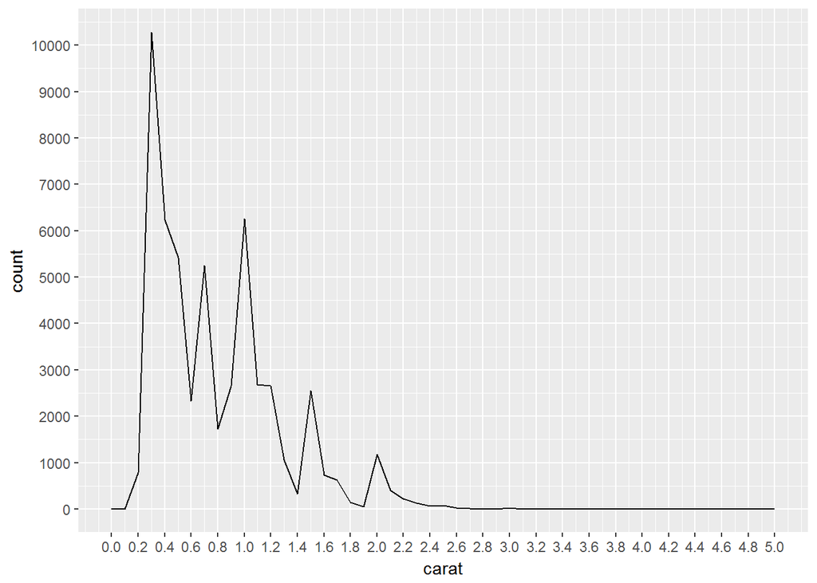

```r
qplot(x=carat, data = subset(diamonds, !is.na(price)),
      geom='freqpoly',
      binwidth= 0.1)+
  scale_x_continuous(limits = c(0,5), breaks = seq(0,5,0.2))+
  scale_y_continuous(breaks = seq(0,10000,1000))
```

### Scatterplot Price vs x GGPLOT

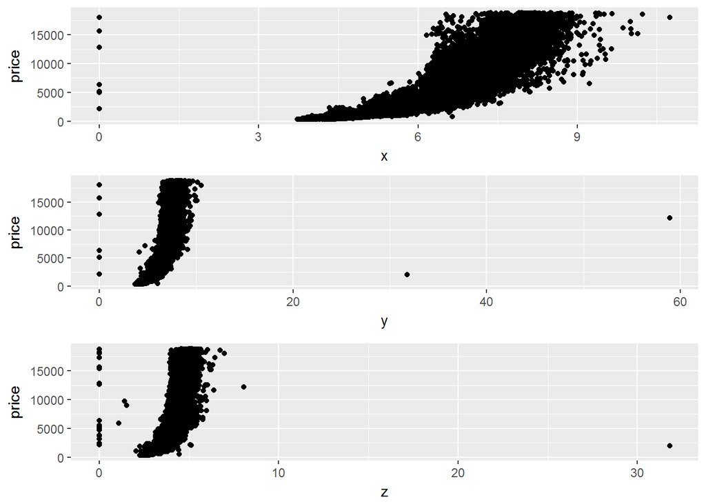

```r
p1 <- ggplot(data = diamonds, aes(x = x, y = price))+
  geom_point()

p2 <- ggplot(data = diamonds, aes(x = y, y = price))+
  geom_point()

p3 <- ggplot(data = diamonds, aes(x = z, y = price))+
  geom_point()

library(gridExtra)
grid.arrange(p1,p2,p3, ncol=1)
```

## Correlation price and x

```r
with(diamonds, cor.test(x, price, method = 'pearson'))
```

```
##
##  Pearson's product-moment correlation
##
## data:  x and price
## t = 440.16, df = 53938, p-value < 2.2e-16
## alternative hypothesis: true correlation is not equal to 0
## 95 percent confidence interval:
##  0.8825835 0.8862594
## sample estimates:
##       cor
## 0.8844352
```

```r
with(diamonds, cor.test(y, price, method = 'pearson'))
```

```
##
##  Pearson's product-moment correlation
##
## data:  y and price
## t = 401.14, df = 53938, p-value < 2.2e-16
## alternative hypothesis: true correlation is not equal to 0
## 95 percent confidence interval:
##  0.8632867 0.8675241
## sample estimates:
##       cor
## 0.8654209
```

```r
with(diamonds, cor.test(z, price, method = 'pearson'))
```

```
##
##  Pearson's product-moment correlation
##
## data:  z and price
## t = 393.6, df = 53938, p-value < 2.2e-16
## alternative hypothesis: true correlation is not equal to 0
## 95 percent confidence interval:
##  0.8590541 0.8634131
## sample estimates:
##       cor
## 0.8612494
```

### Scatterplot price vs depth

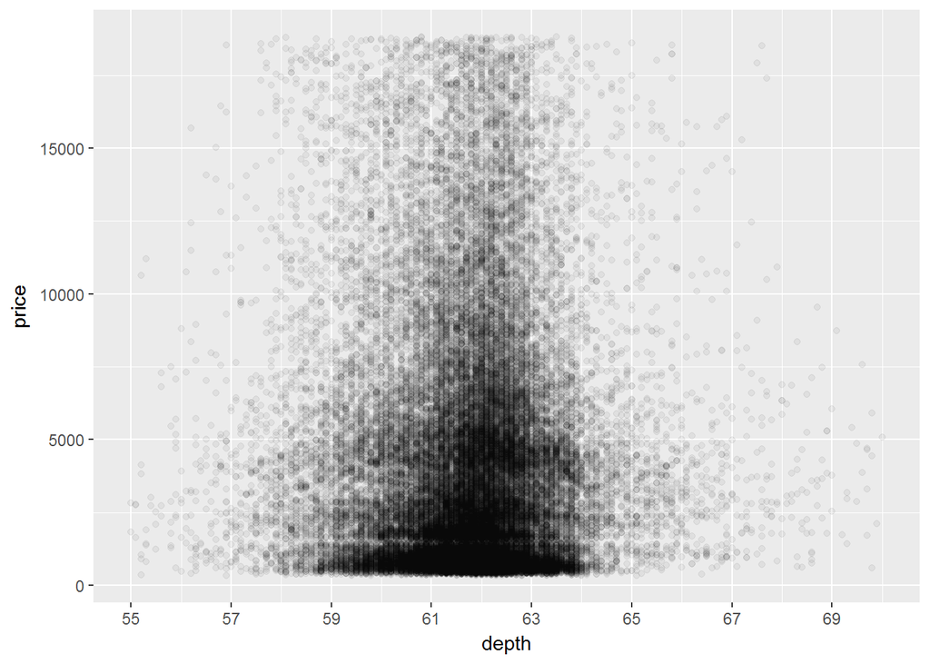

```r
ggplot(data = diamonds, aes(x = depth, y = price))+
  geom_point(alpha = 1/20)+
  scale_x_continuous(limits = c(55,70), breaks = seq(55,70,2))
```

```r
with(diamonds, cor.test(price, depth, method = 'pearson'))
```

```
##
##  Pearson's product-moment correlation
##
## data:  price and depth
## t = -2.473, df = 53938, p-value = 0.0134
## alternative hypothesis: true correlation is not equal to 0
## 95 percent confidence interval:
##  -0.019084756 -0.002208537
## sample estimates:
##        cor
## -0.0106474
```

### Scatterplot Price vs Carat

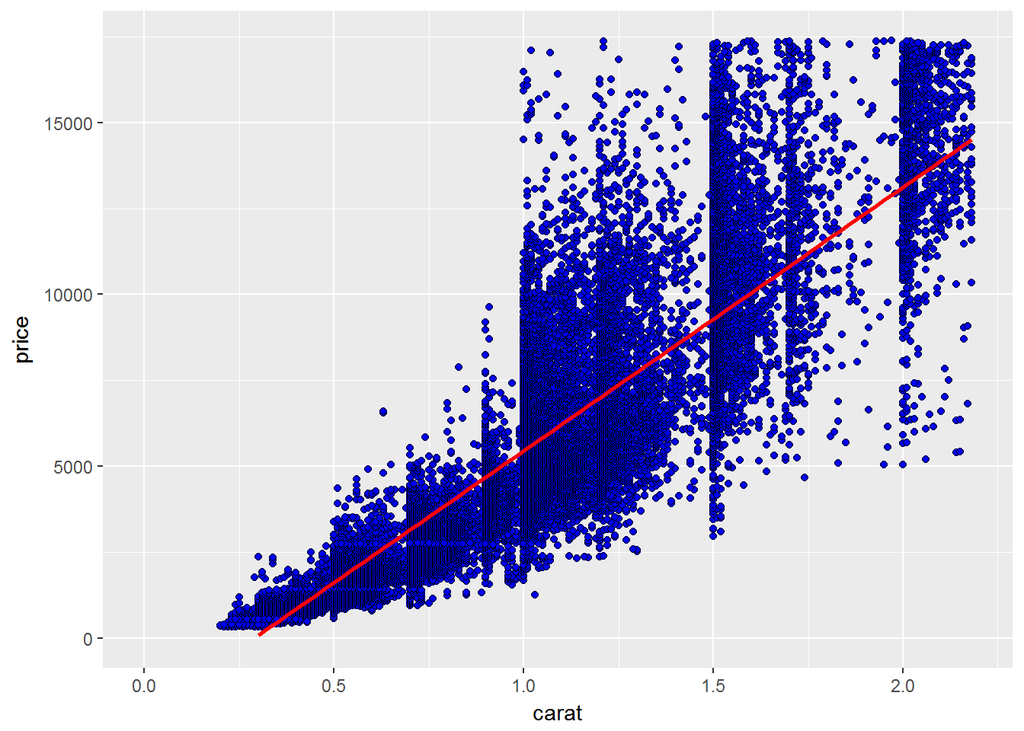

```r
ggplot(data=subset(diamonds, !is.na(price)), aes(x=carat, y=price))+
  geom_point(fill='blue', color='black', shape=21)+
  scale_x_continuous(lim = c(0, quantile(diamonds$carat, probs = 0.99)))+
  scale_y_continuous(lim = c(0, quantile(diamonds$price, probs= 0.99)))+
  stat_smooth(method = 'lm', color = 'red')
```

### Calculating Volume of the diamonds, Scatterplot and Number of diamonds with volume == 0

```r
diamonds$volume <- diamonds$x * diamonds$y * diamonds$z
summary(diamonds$volume)
```

```
##    Min. 1st Qu.  Median    Mean 3rd Qu.    Max.
##    0.00   65.14  114.80  129.80  170.80 3841.00
```

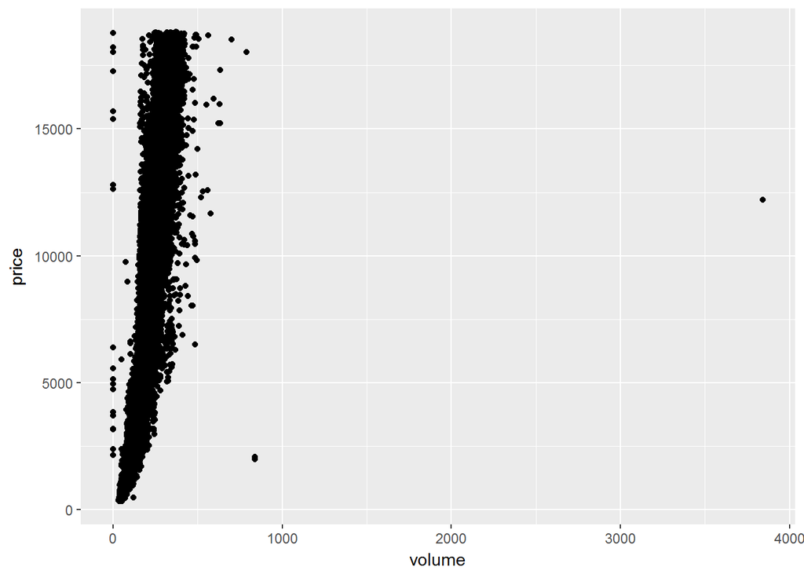

```r
ggplot(data=diamonds, aes(volume, price))+
  geom_point()
```

```r
library(plyr)
count(diamonds$volume == 0)
```

```
##       x  freq
## 1 FALSE 53920
## 2  TRUE    20
```

```r
detach("package:plyr", unload=TRUE)
```

# Correlation price and volume

```r
sub_diamonds<- subset(diamonds, diamonds$volume > 0 & diamonds$volume < 1000)
with(sub_diamonds, cor.test(volume, price, method = 'pearson'))
```

```
##
##  Pearson's product-moment correlation
##
## data:  volume and price
## t = 552.57, df = 53917, p-value < 2.2e-16
## alternative hypothesis: true correlation is not equal to 0
## 95 percent confidence interval:
##  0.9206321 0.9231659
## sample estimates:
##       cor
## 0.9219088
```

## Scatterplot Price vs Volume-subset

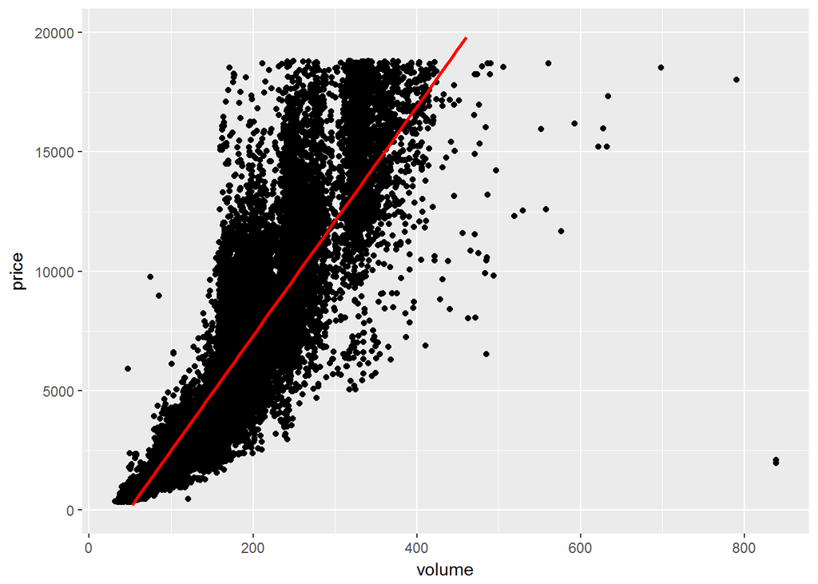

```r
ggplot(data = sub_diamonds, aes(x=volume, y = price))+
  geom_point()+
  scale_y_continuous(limits=c(0,20000))+
  geom_smooth(method = 'lm', color = 'red', formula = y~x)
```

## DiamondsByClarity data frame

```r
library(dplyr)
diamondsByClarity <- diamonds %>% group_by(clarity) %>%
  summarise(mean_price = mean(price),median_price = median(price),
            max_price = max(price),
            min_price = min(price),
            n= n())
diamondsByClarity
```

```
## # A tibble: 8 × 6
##   clarity mean_price median_price max_price min_price     n
##     <ord>      <dbl>        <dbl>     <int>     <int> <int>
## 1      I1   3924.169         3344     18531       345   741
## 2     SI2   5063.029         4072     18804       326  9194
## 3     SI1   3996.001         2822     18818       326 13065
## 4     VS2   3924.989         2054     18823       334 12258
## 5     VS1   3839.455         2005     18795       327  8171
## 6    VVS2   3283.737         1311     18768       336  5066
## 7    VVS1   2523.115         1093     18777       336  3655
## 8      IF   2864.839         1080     18806       369  1790
```

## Bar Plots for diamonds by clarity and diamonds by color

```r
diamonds_by_clarity <- group_by(diamonds, clarity)
diamonds_mp_by_clarity <- summarise(diamonds_by_clarity, mean_price = mean(price))

diamonds_by_color <- group_by(diamonds, color)
diamonds_mp_by_color <- summarise(diamonds_by_color, mean_price = mean(price))

head(diamonds_by_clarity)
```

```
## Source: local data frame [6 x 12]
## Groups: clarity [5]
##
##   carat       cut color clarity depth table price     x     y     z
##   <dbl>     <ord> <ord>   <ord> <dbl> <dbl> <int> <dbl> <dbl> <dbl>
## 1  0.23     Ideal     E     SI2  61.5    55   326  3.95  3.98  2.43
## 2  0.21   Premium     E     SI1  59.8    61   326  3.89  3.84  2.31
## 3  0.23      Good     E     VS1  56.9    65   327  4.05  4.07  2.31
## 4  0.29   Premium     I     VS2  62.4    58   334  4.20  4.23  2.63
## 5  0.31      Good     J     SI2  63.3    58   335  4.34  4.35  2.75
## 6  0.24 Very Good     J    VVS2  62.8    57   336  3.94  3.96  2.48
## # ... with 2 more variables: price_per_carat <int>, volume <dbl>
```

```r
head(diamonds_mp_by_clarity)
```

```
## # A tibble: 6 × 2
##   clarity mean_price
##     <ord>      <dbl>
## 1      I1   3924.169
## 2     SI2   5063.029
## 3     SI1   3996.001
## 4     VS2   3924.989
## 5     VS1   3839.455
## 6    VVS2   3283.737
```

```r
head(diamonds_mp_by_color)
```

```
## # A tibble: 6 × 2
##   color mean_price
##   <ord>      <dbl>
## 1     D   3169.954
## 2     E   3076.752
## 3     F   3724.886
## 4     G   3999.136
## 5     H   4486.669
## 6     I   5091.875
```

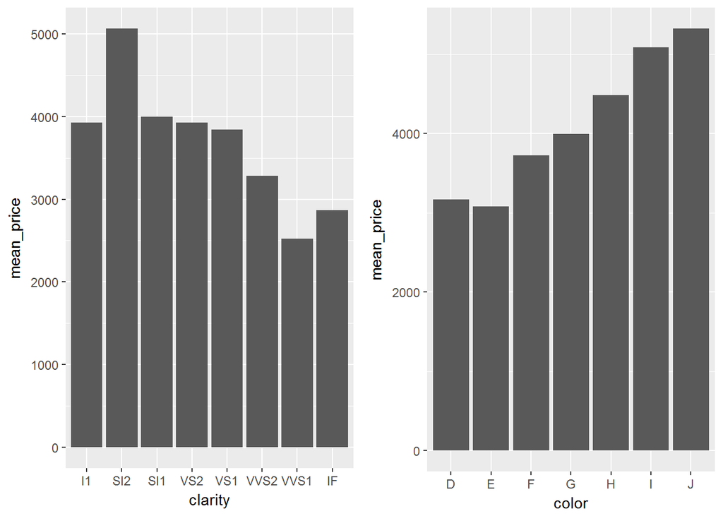

```r
p1 <- ggplot(data = diamonds_mp_by_clarity, aes(x= clarity, y= mean_price))+
  geom_bar(stat = 'identity')
p2 <- ggplot(data = diamonds_mp_by_color, aes(x= color, y= mean_price))+
  geom_bar(stat = 'identity')

grid.arrange(p1, p2, ncol=2)
```

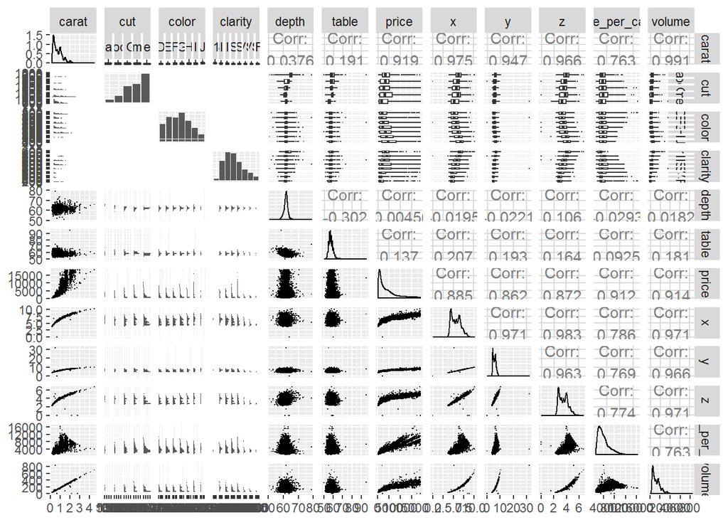

```r
library(ggplot2)
library(GGally)
library(scales)
library(memisc)
# sample 10,000 diamonds from the data set
set.seed(20022012)
diamond_samp <- diamonds[sample(1:length(diamonds$price), 10000), ]
ggpairs(diamond_samp,
  lower = list(continuous = wrap("points", shape = I('.'))),
  upper = list(combo = wrap("box", outlier.shape = I('.'))))
```

```r
#ggsave(file = "ScatterMatrix-Diamonds.pdf")
```

### The Demand of Diamonds

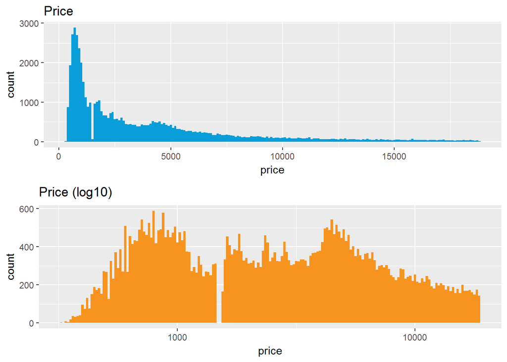

```r
plot1 <- qplot(data = diamonds, x= price, binwidth = 100, fill = I('#099DD9')) +
  ggtitle('Price')

plot2 <- qplot(data= diamonds, x= price, binwidth = 0.01, fill = I('#F79420')) +
  scale_x_log10()+
  ggtitle('Price (log10)')

grid.arrange(plot1, plot2, ncol=1)
```

### Price vs. Carat and Clarity

# If the distribution of a variable has a positive skew, taking a natural logarithm of the variable sometimes helps fitting the variable into a model. Log transformations make positively skewed distribution more normal. Also, when a change in the dependent variable is related with percentage change in an independent variable, or vice versa, the relationship is better modeled by taking the natural log of either or both of the variables.

```r
### Create a new function to transform the carat variable

cuberoot_trans = function() trans_new('cuberoot', transform = function(x) x^(1/3),
                                      inverse = function(x) x^3)
```

### Scatterplot Price vs. Carat and Clarity using Cube root transformation and Log transformation

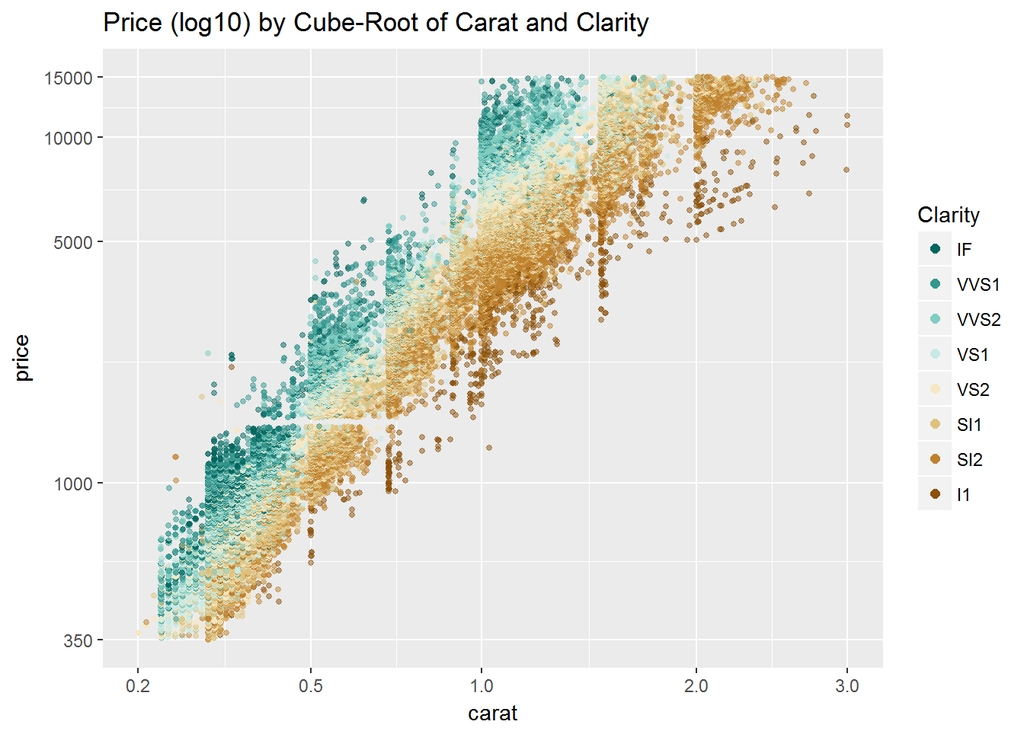

```r
library(RColorBrewer)

ggplot(aes(x = carat, y = price, color = clarity), data = diamonds) +
  geom_point(alpha = 0.5, size = 1, position = 'jitter') +
  scale_color_brewer(type = 'div',
    guide = guide_legend(title = 'Clarity', reverse = T,
    override.aes = list(alpha = 1, size = 2))) +
  scale_x_continuous(trans = cuberoot_trans(), limits = c(0.2, 3),
    breaks = c(0.2, 0.5, 1, 2, 3)) +
  scale_y_continuous(trans = log10_trans(),limits = c(350, 15000),
    breaks = c(350, 1000, 5000, 10000, 15000)) +
  ggtitle('Price (log10) by Cube-Root of Carat and Clarity')
```

### We can infer that the Price increases with increase in carat and with better Clarity and more importantly we can see that for the same value of carat, the price is higher for better clarity of diamonds

### Price vs. Carat and Cut

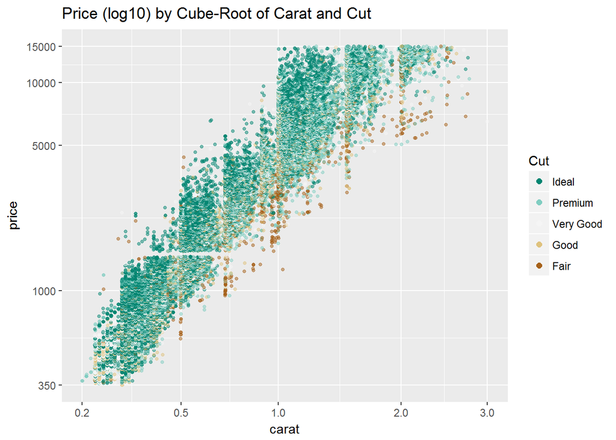

```r
ggplot(aes(x = carat, y = price, color = cut), data = diamonds) +
  geom_point(alpha = 0.5, size = 1, position = 'jitter') +
  scale_color_brewer(type = 'div',
                     guide = guide_legend(title = 'Cut', reverse = T,
                                          override.aes = list(alpha = 1, size = 2))) +
  scale_x_continuous(trans = cuberoot_trans(), limits = c(0.2, 3),
                     breaks = c(0.2, 0.5, 1, 2, 3)) +
  scale_y_continuous(trans = log10_trans(), limits = c(350, 15000),
                     breaks = c(350, 1000, 5000, 10000, 15000)) +
  ggtitle('Price (log10) by Cube-Root of Carat and Cut')
```

### Price vs. Carat and Color

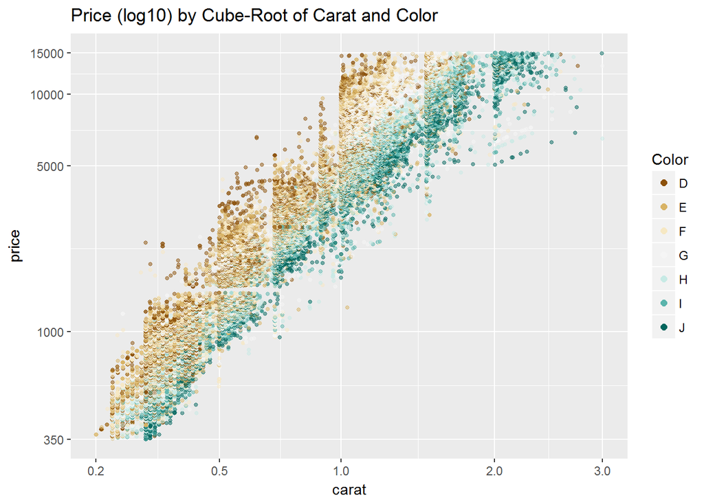

```r
ggplot(aes(x = carat, y = price, color = color), data = diamonds) +
  geom_point(alpha = 0.5, size = 1, position = 'jitter') +
  scale_color_brewer(type = 'div',
                     guide = guide_legend(title = 'Color',                                           override.aes = list(alpha = 1, size = 2))) +
  scale_x_continuous(trans = cuberoot_trans(), limits = c(0.2, 3),
                     breaks = c(0.2, 0.5, 1, 2, 3)) +
  scale_y_continuous(trans = log10_trans(), limits = c(350, 15000),
                     breaks = c(350, 1000, 5000, 10000, 15000)) +
  ggtitle('Price (log10) by Cube-Root of Carat and Color')
```

### The price of diamonds is higher for colors D and E as compared to the others.

### Building the Linear Model

```r
m1 <- lm(I(log(price)) ~ I(carat^(1/3)), data = diamonds)
m2 <- update(m1, ~ . + carat)
m3 <- update(m2, ~ . + cut)
m4 <- update(m3, ~ . + color)
m5 <- update(m4, ~ . + clarity)
mtable(m1, m2, m3, m4, m5, sdigits = 3)
```

```
##
## Calls:
## m1: lm(formula = I(log(price)) ~ I(carat^(1/3)), data = diamonds)
## m2: lm(formula = I(log(price)) ~ I(carat^(1/3)) + carat, data = diamonds)
## m3: lm(formula = I(log(price)) ~ I(carat^(1/3)) + carat + cut, data = diamonds)
## m4: lm(formula = I(log(price)) ~ I(carat^(1/3)) + carat + cut + color,
##     data = diamonds)
## m5: lm(formula = I(log(price)) ~ I(carat^(1/3)) + carat + cut + color +
##     clarity, data = diamonds)
##
## =============================================================================
##                       m1          m2          m3         m4          m5
## -----------------------------------------------------------------------------
##   (Intercept)      2.821***    1.039***    0.874***    0.932***   0.415***
##                   (0.006)     (0.019)     (0.019)     (0.017)    (0.010)
##   I(carat^(1/3))   5.558***    8.568***    8.703***    8.438***   9.144***
##                   (0.007)     (0.032)     (0.031)     (0.028)    (0.016)
##   carat                       -1.137***   -1.163***   -0.992***  -1.093***
##                               (0.012)     (0.011)     (0.010)    (0.006)
##   cut: .L                                  0.224***    0.224***   0.120***
##                                           (0.004)     (0.004)    (0.002)
##   cut: .Q                                 -0.062***   -0.062***  -0.031***
##                                           (0.004)     (0.003)    (0.002)
##   cut: .C                                  0.051***    0.052***   0.014***
##                                           (0.003)     (0.003)    (0.002)
##   cut: ^4                                  0.018***    0.018***  -0.002
##                                           (0.003)     (0.002)    (0.001)
##   color: .L                                           -0.373***  -0.441***
##                                                       (0.003)    (0.002)
##   color: .Q                                           -0.129***  -0.093***
##                                                       (0.003)    (0.002)
##   color: .C                                            0.001     -0.013***
##                                                       (0.003)    (0.002)
##   color: ^4                                            0.029***   0.012***
##                                                       (0.003)    (0.002)
##   color: ^5                                           -0.016***  -0.003*
##                                                       (0.003)    (0.001)
##   color: ^6                                           -0.023***   0.001
##                                                       (0.002)    (0.001)
##   clarity: .L                                                     0.907***
```

[output cut: 10 more lines]

```
##                                                                  (0.002)
##   clarity: ^7                                                     0.032***
##                                                                  (0.001)
## -----------------------------------------------------------------------------
##   R-squared            0.924       0.935       0.939      0.951       0.984
##   adj. R-squared       0.924       0.935       0.939      0.951       0.984
##   sigma                0.280       0.259       0.250      0.224       0.129
##   F               652012.063  387489.366  138654.523  87959.467  173791.084
##   p                    0.000       0.000       0.000      0.000       0.000
##   Log-likelihood   -7962.499   -3631.319   -1837.416   4235.240   34091.272
##   Deviance          4242.831    3613.360    3380.837   2699.212     892.214
##   AIC              15930.999    7270.637    3690.832  -8442.481  -68140.544
##   BIC              15957.685    7306.220    3761.997  -8317.942  -67953.736
##   N                53940       53940       53940      53940       53940
## =============================================================================
```

```r
thisDiamond = data.frame(carat = 1.00, cut = "Very Good",
                         color = "I", clarity="VS1")
modelEstimate = predict(m5, newdata = thisDiamond,
                        interval="prediction", level = .95)

modelEstimate
```

```
##        fit     lwr      upr
## 1 8.420202 8.16803 8.672375
```